# [Tutorial] TCGA

```r
d_luad0 <- GDCprepare(query)
```

[output not shown]

[output cut: 539 more lines]

[output not shown]

```
Starting to add information to samples
 => Add clinical information to samples
 => Adding TCGA molecular information from marker papers
 => Information will have prefix 'paper_'
luad subtype information from:doi:10.1038/nature13385
From the 60483 genes we couldn't map 3881
```

```r
d_luad = as.data.frame(d_luad0@colData)
```

Now we are downloading the dataset for Lung Squamous Cell Carcinoma (LUSC).

```r
query <- GDCquery(project = "TCGA-LUSC",
                  data.category = "Transcriptome Profiling",
                  data.type = "Gene Expression Quantification",
                  workflow.type = "HTSeq - FPKM-UQ")
```

```
--------------------------------------
o GDCquery: Searching in GDC database
--------------------------------------
Genome of reference: hg38
--------------------------------------------
oo Accessing GDC. This might take a while...
--------------------------------------------
ooo Project: TCGA-LUSC
--------------------
oo Filtering results
--------------------
ooo By data.type
ooo By workflow.type
----------------
oo Checking data
----------------
ooo Check if there are duplicated cases
ooo Check if there results for the query
-------------------
o Preparing output
-------------------
```

```r
GDCdownload(query)
```

```
Downloading data for project TCGA-LUSC
GDCdownload will download 551 files. A total of 291.468297 MB
Downloading as: Wed_Oct_27_10_56_21_2021.tar.gz
```

[output not shown]

[output cut: 13535 more lines]

[output not shown]

```r
d_lusc0 <- GDCprepare(query)
```

[output not shown]

[output cut: 497 more lines]

[output not shown]

```
Starting to add information to samples
 => Add clinical information to samples
 => Adding TCGA molecular information from marker papers
 => Information will have prefix 'paper_'
lusc subtype information from:doi:10.1038/nature11404
From the 60483 genes we couldn't map 3881
```

```r
d_lusc = as.data.frame(d_lusc0@colData)
```

For simplicity, we are choosing only genes on the chromosome 1. Please save to the Rdata into your working folder.

```r
library(SummarizedExperiment)
e_luad = assay(d_luad0)
e_lusc = assay(d_lusc0)

g_luad = d_luad0@rowRanges %>% as.data.frame() %>% filter(seqnames=='chr1') %>% pull(ensembl_gene_id)
g_lusc = d_lusc0@rowRanges %>% as.data.frame() %>% filter(seqnames=='chr1') %>% pull(ensembl_gene_id)
e_luad = e_luad[g_luad,]
e_lusc = e_lusc[g_lusc,]

save(d_luad, d_lusc, e_luad, e_lusc, file='data.TCGA_LUAD_LUSC.gene_expression.Rdata')
```

## 2.2 Get the file from the link

You can download the data from this link. Please save this file to the working folder. Then, load the objects to your workspace.

```r
load('data.TCGA_LUAD_LUSC.gene_expression.Rdata')
```

# 3. Explore the input dataset

Let’s explore which columns are provided in the LUAD dataset.

```r
colnames(d_luad)
```

```
 [1] "barcode"
 [2] "patient"
 [3] "sample"
 [4] "shortLetterCode"
 [5] "definition"
 [6] "sample_submitter_id"
 [7] "sample_type_id"
 [8] "sample_id"
 [9] "sample_type"
[10] "days_to_collection"
[11] "state"
[12] "initial_weight"
[13] "intermediate_dimension"
[14] "pathology_report_uuid"
[15] "submitter_id"
```

[output cut: 71 more lines]

Do we see the same columns for the LUSC dataset?

```r
colnames(d_lusc)
```

```
 [1] "barcode"
 [2] "patient"
 [3] "sample"
 [4] "shortLetterCode"
 [5] "definition"
 [6] "sample_submitter_id"
 [7] "sample_type_id"
 [8] "sample_id"
 [9] "sample_type"
[10] "days_to_collection"
[11] "state"
[12] "initial_weight"
[13] "intermediate_dimension"
[14] "pathology_report_uuid"
[15] "submitter_id"
```

[output cut: 65 more lines]

## 3.1 Which tissues or samples are available for your analysis?

Lung cancer samples in the dataset are provided in tumor or normal tissues. The column shortLetterCode contains Sample Type Codes to describe the type of tissues collected in the dataset.

- TP: Primary solid Tumor
- TR: Recurrent solid Tumor
- NT: Solid Tissue Normal

Check which samples are included in the LUAD dataset.

```r
d_luad %>% dplyr::count(shortLetterCode)
```

| shortLetterCode | n |
| --- | --- |
| NT | 59 |
| TP | 533 |
| TR | 2 |

```r
#오류가 나서 코드 살짝 수정했습니다
```

Check which samples are included in the LUSC dataset.

```r
d_lusc %>% dplyr::count(shortLetterCode)
```

| shortLetterCode | n |
| --- | --- |
| NT | 49 |
| TP | 502 |

Let’s make a simple bar plot to compare the number of tissues between two tissue types. We will look at the LUAD samples first.

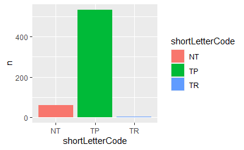

```r
d_luad %>%
  dplyr::count(shortLetterCode) %>%
  ggplot(., aes(shortLetterCode, n, fill=shortLetterCode)) +
  geom_bar(stat="identity", position=position_dodge())
```

Now we can plot the LUSC samples.

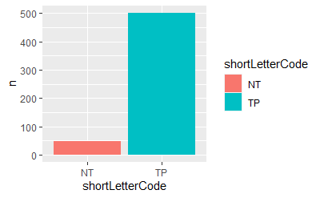

```r
d_lusc %>%
  dplyr::count(shortLetterCode) %>%
  ggplot(., aes(shortLetterCode, n, fill=shortLetterCode)) +
  geom_bar(stat="identity", position=position_dodge())
```

We made two separate plots for the LUAD and LUSC dataset. It would be great if we can merge them into one plot. Here I put the code for this. It would be good practice if you comment or delete the line that you don’t understand fully, you will compare the difference between outcomes. Also, please figure out what Qs do in this plot.

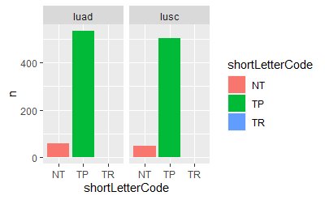

```r
bind_rows(d_luad %>%
            mutate(type='luad') %>%
            select(type, shortLetterCode, tumor_stage),
          d_lusc %>%
            mutate(type='lusc') %>%
            select(type, shortLetterCode, tumor_stage)) %>%
  dplyr::count(shortLetterCode, type) %>%
  complete(type, shortLetterCode, fill = list(n = 0)) %>% # Q1: What is this?
  ggplot(., aes(shortLetterCode, n, fill=shortLetterCode)) +
  geom_bar(stat="identity", position=position_dodge()) +
  facet_wrap(~type, scales = 'free_x', ncol=5) # Q2: What is this?
```

```r
#A1: This code changes NA to 0, making us identify variables that do not have the value in the graph.
#A2: This code shows both luad and lusc data with each cancer type.
```